# NYC_Taxi

```r
data <- readr::read_csv('green_tripdata_2015-09.csv',col_names = TRUE)
```

```r
data <- mutate_at(data, .vars = vars(VendorID,Store_and_fwd_flag,RateCodeID,Payment_type,Trip_type),
                  .funs = as.factor)
```

```r
diagnose(data)
```

Basically saying, the data looks pretty clean almost without missing value. Only one column(Ehail_fee) is empty and Trip type has 4 missing value.

But actually there are more missing and uncorrect situations. Like the pickup or drop off longitude and latitude are zero. And like passenger count is 0 which means the driver miss type or not type the actual number of passenger. Or the ride has a very big travel distance but a small number of payment which is unusual.

I will talke about this later when I visualize the data set.

But generally, the quality of data is pretty good.

```r
numeric <- diagnose_numeric(data)
numeric
```

```r
category <- diagnose_category(data,top= 5)
category %>% arrange(variables,levels)%>%select(-N)
```

do some interesting visualization

First of all, there are 20592 records with a 0 distance but the situation is complex with a mean of 3.057 miles and median as 2 miles. There are some outlier with an extra large number of distance. Some long distance travel has a small amount of payment. And I will talk about this speical case later.

Some zero records may cause because of the error of the GPS system and some records do travel very short or cancel after picking up.

The trip distance data is like a normal distribution. I think it is reasonable.

```r
data %>%ggplot(aes(x=Trip_distance))+
  geom_histogram(bins = 30)+ scale_x_log10()+ ggtitle( "Distribution of Trip Distance")
```

It is very clear that most of the ride has only one passenger and some of the record may has 0 passenger. If I hope to train a model, I need to filter out this data.

```r
data %>%
  ggplot(aes(x=Passenger_count))+ geom_bar(stat = 'count')+ ggtitle( "Distribution of Passenger count")+scale_x_discrete(limits= c(0:9))
data %>%
  ggplot(aes(x=Passenger_count))+ geom_bar(stat = 'count')+ ggtitle( "Distribution of Passenger count")+scale_x_discrete(limits= c(0:9))+scale_y_log10()
```

Total_amount has a mean of 15 dollar and a median of 11.76 dollar. 4172 Zero record and 2417 record smaller than 0. I think the amount smaller than 0 mean the transaction is speical and the company may pay extra money to customer because of complaint or the minus charge is recorded by mistake.

```r
data %>%ggplot(aes(x=Total_amount))+
  geom_histogram(bins=200)+ ggtitle( "Distribution of Total amount")+ scale_y_log10()
```

visualize part of the pick up points in the map and there are mainly in the Manhattan island.

```r
sample <- sample_n(data, 1000)%>%
  filter(Pickup_longitude !=0)%>%
  filter(Pickup_latitude !=0)
leaflet(data=sample) %>%
    addTiles() %>%  # Add default OpenStreetMap map tiles
    addCircleMarkers(~ Pickup_longitude, ~Pickup_latitude, radius = 1,
                   color = "red", fillOpacity = 0.2)
```

Because of limited time, I am not going to visualize the column one by one. Let continue to third part.

Find interesting trip statistics grouped by hour

do some feature engineer at the beginning

```r
data <- data %>%
  mutate(pick_day = format(lpep_pickup_datetime, "%d"))%>%
  mutate(drop_day = format(Lpep_dropoff_datetime, "%d"))%>%
  mutate(pick_hour = format(lpep_pickup_datetime, "%H"))%>%
  mutate(drop_hour = format(Lpep_dropoff_datetime, "%H"))%>%
  mutate(duration_minute = round((Lpep_dropoff_datetime-lpep_pickup_datetime)/60,digit =2))
```

There are lots of interesting finding if we group by hour and see the relationship between hour and cost or number of passenger. I pick up three most interesting features to present here.

The two features are different.

Average cost per mile will be highly affected by a traffic jam in New York rush hour and the cost per mile will increase because of traffic jam.At the same time ,in rush hour the travel distance is short. So considering the fare, the average price per mile increase in rush hour.

Before dawn, the cost per mile is low and that happens because before dawn the trip has longer distance(may be go to the air port) so the average per mile is low. The price per minute increase because it is fast and good traffic condition.

```r
hour_data <- data %>% group_by(pick_hour)%>%summarise(mean_amount = mean(Total_amount),mean_distance = mean(Trip_distance),mean_passenger = mean(Passenger_count),mean_duration= mean(duration_minute))
hour_data <- hour_data %>%
  mutate(amount_per_minute =  mean_amount/as.numeric(mean_duration))%>%
  mutate(amount_per_mile =  mean_amount/mean_distance)
head(hour_data)
hour_data %>% ggplot(aes(x=pick_hour,y=amount_per_minute))+geom_bar(stat="identity",fill = "#FF6666")+scale_y_continuous(limits = c(0.5,1), oob = rescale_none)+ggtitle( "Relationship between pick hour and cost per minute")
hour_data %>% ggplot(aes(x=pick_hour,y=amount_per_mile))+geom_bar(stat="identity",fill = "#669eff")+scale_y_continuous(limits = c(4,5.5), oob = rescale_none)+ggtitle( "Relationship between pick hour and cost per mile")

hour_data %>% ggplot(aes(x=pick_hour,y=mean_passenger))+geom_bar(stat="identity",fill = '#3da86b')+scale_y_continuous(limits = c(1.2,1.5), oob = rescale_none)+ggtitle( "Relationship between pick hour and passenger number")
hour_data %>% ggplot(aes(x=pick_hour,y=mean_distance))+geom_bar(stat="identity",fill = '#d136b0')+scale_y_continuous(limits = c(2,4), oob = rescale_none)+ggtitle( "Relationship between pick hour and travel distance")
```

Let’s build a model to research the tips. Before we start, I will clean those incorrect data like 0 passenger and data without longtitude or latitude. Because w ehave 1494926 rows and the data set is big, I can just filter out those outliers and we still have enough data to train.

```r
data <- data %>%
  filter(Pickup_longitude !=0)%>%
  filter(Pickup_latitude !=0)%>%
  filter(Passenger_count !=0 )%>%
  filter(Trip_distance >0)%>%
  filter(duration_minute<24*60 & duration_minute>0.1)%>%
  filter(Tip_amount>=0)%>%
  filter(Total_amount >0)
count(data)
```

| n |
| --- |
| 1465865 |

Before we go to the model, we can do some feature engineer.

The taxi drivers want to know what kind of trip yields better tips.

Better tips have two concepts. One is higher tip amount for one trip. Second is higher tip rate of one trip.

And I can reverse geocoding with Photon from longtitude/latitude to zip code but it takes too much time. So I just put the idea here. And at the same time, I can also use weather data on 2015 Sept to join the dataset I have. I think weather may have important impact on the tip but I don’t have time to do so.

Because usually the speed limit in US is 70 mile/hour ,about 1 mile / minute(In Manhattan it is hard to reach the number),so I need to filter those with avg_speed larger than 1 because there are unusual.

```r
data<- data %>%
  mutate(tips_rate = Tip_amount / Total_amount)%>%
  mutate(weekend = is.weekend(lpep_pickup_datetime))%>%
  mutate(holiday = pick_day == '07')%>%
  mutate(duration_minute = as.numeric(duration_minute))%>%
  mutate(avg_speed = Trip_distance/duration_minute)%>%
  select(-Ehail_fee)%>%
  filter(avg_speed <=1)
```

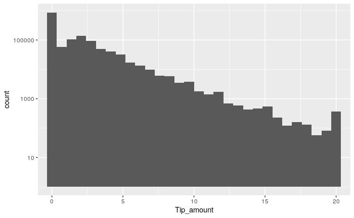

```r
data %>% ggplot(aes(x=Tip_amount))+geom_histogram(bins =30)+ scale_y_log10()+scale_x_continuous(limits = c(0,20), oob = rescale_none)
```

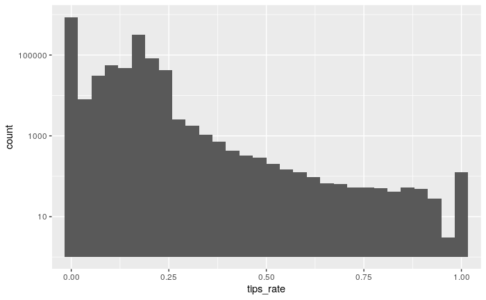

```r
data %>% ggplot(aes(x=tips_rate))+geom_histogram(bins =30)+ scale_y_log10()+scale_x_continuous(limits = c(0,1), oob = rescale_none)
```

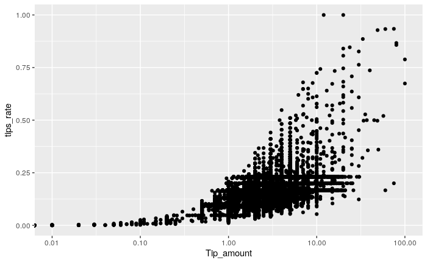

```r
train_pre <- data %>%
  select(Tip_amount,VendorID,Store_and_fwd_flag,RateCodeID,Pickup_longitude,Pickup_latitude,Passenger_count,Trip_distance,Fare_amount,Extra,MTA_tax,Tolls_amount,improvement_surcharge,Total_amount,Payment_type,Trip_type,pick_day,pick_hour,duration_minute,tips_rate,weekend,holiday,avg_speed)

train_pre <- sample_n(train_pre, 100000)
train_pre %>% ggplot(aes(x=Tip_amount,y=tips_rate))+geom_point()+scale_x_log10()
```

From the graph we can see Tip_amount has the strong positive correlationship with tip rate. I recall my experience when I talked with an Uber driver and he told me he cared about the tip amount rather than the tip rate. Because amount is directly and rate is calculated.

```r
lapply(train_pre,class)
```

```
$Tip_amount
[1] "numeric"

$VendorID
[1] "factor"

$Store_and_fwd_flag
[1] "factor"

$RateCodeID
[1] "factor"

$Pickup_longitude
[1] "numeric"

$Pickup_latitude
[1] "numeric"

$Passenger_count
[1] "numeric"

$Trip_distance
[1] "numeric"

$Fare_amount
[1] "numeric"

$Extra
[1] "numeric"

$MTA_tax
[1] "numeric"

$Tolls_amount
[1] "numeric"

$improvement_surcharge
[1] "numeric"

$Total_amount
```

[output cut: 13 more lines]

```

$duration_minute
[1] "numeric"

$tips_rate
[1] "numeric"

$weekend
[1] "logical"

$holiday
[1] "logical"

$avg_speed
[1] "numeric"
```

```r
train_pre <- train_pre %>%
  mutate(pick_day =as.factor(pick_day))%>%
  mutate(pick_hour = as.factor(pick_hour))
```

```r
train_pre<-train_pre %>%
  select(-tips_rate)%>%
  select(-Fare_amount)%>%
  select(-Total_amount)%>%
  select(-Tolls_amount)%>%
  select(-pick_day)%>%
  mutate(pick_hour = as.numeric(pick_hour))%>%
  mutate(midnight =  pick_hour >=0 & pick_hour <7)%>%
  mutate(morning =  pick_hour >=7 & pick_hour <13)%>%
  mutate(afterning = pick_hour >=13 &pick_hour <19)%>%
  mutate(evening = pick_hour >=19)%>%
  mutate(rush_hour = (pick_hour>=7 & pick_hour<=10) |(pick_hour>=4 & pick_hour<=7))%>%
  select(-pick_hour)
train <-sample_n(train_pre, 40000)
temp <- anti_join(train_pre,train)
validation <- sample_n(temp,5000)
test<-anti_join(temp,validation)
```

Modelling ,the response variable is Tip_amount.Run a basic model to see what will we get.

```r
result <- lm(Tip_amount~.,data =train)
summary(result)
```

```
Call:
lm(formula = Tip_amount ~ ., data = train)

Residuals:
    Min      1Q  Median      3Q     Max
-27.816  -0.502   0.100   0.425  97.796

Coefficients: (1 not defined because of singularities)
                         Estimate  Std. Error  t value             Pr(>|t|)
(Intercept)           39.22264344 17.42444362    2.251             0.024390 *
VendorID2             -0.03238593  0.02015477   -1.607             0.108093
Store_and_fwd_flagY   -0.19981169  0.11564389   -1.728             0.084028 .
RateCodeID2            1.37338336  0.17923342    7.663   0.0000000000000186 ***
RateCodeID3            2.63729403  0.76306594    3.456             0.000548 ***
RateCodeID4           -1.23396105  0.40671653   -3.034             0.002415 **
RateCodeID5           -0.59893614  0.33411555   -1.793             0.073044 .
Pickup_longitude      -0.21833790  0.20237475   -1.079             0.280648
Pickup_latitude       -1.26319221  0.15041190   -8.398 < 0.0000000000000002 ***
Passenger_count        0.02262040  0.00798364    2.833             0.004609 **
Trip_distance          0.28051774  0.00338789   82.800 < 0.0000000000000002 ***
Extra                 -0.04193200  0.02868102   -1.462             0.143746
MTA_tax               -4.24866222  1.27480966   -3.333             0.000861 ***
improvement_surcharge  0.79201392  1.08539346    0.730             0.465577
Payment_type2         -2.37165341  0.01682801 -140.935 < 0.0000000000000002 ***
Payment_type3         -2.37452975  0.19292173  -12.308 < 0.0000000000000002 ***
Payment_type4         -2.42941058  0.18151488  -13.384 < 0.0000000000000002 ***
Trip_type2            -1.48310712  0.61781410   -2.401             0.016374 *
duration_minute       -0.00050535  0.00009005   -5.612   0.0000000201637041 ***
weekendTRUE           -0.03686810  0.01915835   -1.924             0.054313 .
holidayTRUE           -0.08682777  0.04921681   -1.764             0.077708 .
avg_speed             -1.59683043  0.11178189  -14.285 < 0.0000000000000002 ***
midnightTRUE          -0.01714312  0.02621699   -0.654             0.513184
morningTRUE            0.03579105  0.03260218    1.098             0.272293
afterningTRUE          0.04308979  0.02171284    1.985             0.047204 *
eveningTRUE                    NA          NA       NA                   NA
rush_hourTRUE          0.01651250  0.02823118    0.585             0.558616
---
Signif. codes:  0 ‘***’ 0.001 ‘**’ 0.01 ‘*’ 0.05 ‘.’ 0.1 ‘ ’ 1

Residual standard error: 1.623 on 39974 degrees of freedom
Multiple R-squared:  0.4724,    Adjusted R-squared:  0.4721
F-statistic:  1432 on 25 and 39974 DF,  p-value: < 0.00000000000000022
```

```r
pred <- predict(result,validation)
```

```
prediction from a rank-deficient fit may be misleading
```

```r
validation <-data.frame(validation,pred)
mae(validation$Tip_amount,validation$pred)
```

```
[1] 0.8135132
```

mae 0.813